# nb_08_Salifort_Motors_project_XGBoost_Model

**ML Models**

**Client Documentation**

# Salifort Motors - ML Modelling - XGBoost

### Document Information

| Document Title | Salifort Motors - ML Modelling - XGBoost |
| --- | --- |
| Author | Rod Slater |
| Version | 1.0 |
| Created | 01-11-2023 |
| Modified | 16-11-2023 |

### Client Details

| Client Name | Salifort Motors |
| --- | --- |
| Client Contact | Mr HR Team |
| Client Email | hr@salifortmotors.it |
| Client Project | HR Team Data Driven Solutions from Machine Learning Models |

### Document Overview

ML Modelling using XGBoost for HR Data provided by Salifort Motors. This notebook details the XGBoost Modelling process and performance comparisons

# XGBoost Model

### Notes

- The fit process for XGBoost models can take a long time to run, suggest using pickle save and load.
- Remember to use unique variable names for the different models.
- The GridSearch can take 20-30 mins, suggest using the `refit` option flags in this code once the model has been fitted and saved once.
- Salifort Motors - ML Modelling - XGBoost
  - Document Information
  - Client Details
  - Document Overview
- XGBoost Model
  - Notes
  - Initialise Notebook
    - Import Packages
    - Set Pandas Options
    - Initialise Notebook Options
    - Define Functions
      - beepr() - make a beep when cell complete (typically fit ops)
      - display_results() - Function to retrieve scores from Results.csv and display them
      - format_GS_results(model_name: str, model_object: object, metric: str) - Function to get scores from Gridsearch
      - make_lr_results(model_name: str, model_object: object, X_var: str, y_var: str, y_pred_var: str)
      - classification_report_summary(name: str, y_var: str, y_pred_var: str)
      - Read / Write Pickle Function
- Construct Models - XGBoost
  - XGBoost - `xg1` - All Features included
    - Import data - `xg1-ALLFeat`
    - Code flags:
    - Prepare data for modelling - `xg1-ALLFeat`
    - Isolate the outcome and feature variables - `xg1-ALLFeat`
    - Train Test split data - `xg1-ALLFeat`
    - Instantiate model - XGBoost - GridSearch - `model_xg1` - Train data
    - Fit Data - XGBoost - Grid Search - `model_xg1` - Train data
    - Read / Write Pickle
    - Get GridSearch best results - XGBoost - `model_xg1` - Train data
    - Prepare and Save Results - XGBoost - GridSearch - `model_xg1` - Train data
    - Performance Results & Comparisons - GridSearch - model_xg1 - Train data
    - Display Results
    - Make Predictions - XGBoost - best_model - `model_xg1` - Test data
    - Classification Report
    - Prepare and Save Results - `model_xg1` - Test Data
  - Performance Results & Comparisons - `model_xg1` - Test data
    - Display Results
    - Make Predictions - XGBoost - best_model - `model_xg1` - Train data
    - Classification Report
    - Prepare and Save Results - `model_xg1` - Train data
  - Performance Results & Comparisons - `model_xg1` - Train data
    - Display Results
    - Feature Importance - `model_xg1` - Train data
  - Construct Model - XGBoost - `xg2` - No Departments
    - Import Data - `xg2` - No Departments
      - Code flags:
    - Prepare data for modelling - `xg2`
    - Isolate the outcome and feature variables - `xg2`
    - Train Test split data - `model_xg2`
    - Instantiate model - XGBoost - GridSearch - `model_xg2` - Train data
    - Fit Data - XGBoost - Grid Search - `model_xg2` - Train data
    - Read / Write Pickle
    - Get GridSearch best results - XGBoost - `model_xg2` - Train data
    - Prepare and Save Results - XGBoost - GridSearch - `model_xg2` - Train data
  - Performance Results & Comparisons - GridSearch - `model_xg2` - Train data
    - Display Results
    - Feature Importance - GridSearch - `model_xg2` - Train data
    - Make Predictions - XGBoost - best_model - `model_xg2` - Test data
    - Classification Report
    - Prepare and Save Results - `model_xg2` - Test data
  - Performance Results & Comparisons - `model_xg2` - Test data
    - Display Results
    - Feature Importance - XGBoost - `model_xg2` - Test Data
    - Make Predictions - XGBoost - best_model - `model_xg2` - Train data
    - Classification Report
    - Prepare and Save Results - `model_xg2` - Train data
  - Performance Results & Comparisons - `model_xg2` - Train data
    - Display Results
- Review Results
  - Dataset comparison - XGBoost
  - Model performance
    - Confusion Matrix Heatmap - `model_xg1`
  - Feature Importance
  - Precision / Recall Curve
  - ROC Curve Plot
  - Conclusion, model comparison - XGBoost.

## Initialise Notebook

### Import Packages

```python
# Import packages

# Data manipulation
import numpy as np
import pandas as pd

# Data visualization
import matplotlib.pyplot as plt
import seaborn as sns

# Set Options
pd.set_option('display.max_columns', None)

# Data modelling Imports
from xgboost import XGBClassifier, XGBRegressor, plot_importance

from sklearn.linear_model import LogisticRegression
from sklearn.tree import DecisionTreeClassifier
from sklearn.ensemble import RandomForestClassifier

# For metrics and helpful functions
from sklearn.model_selection import GridSearchCV, train_test_split
from sklearn.metrics import accuracy_score, precision_score, recall_score, precision_recall_fscore_support, \
f1_score, confusion_matrix, ConfusionMatrixDisplay, classification_report, precision_recall_curve, auc
from sklearn import metrics
from sklearn.metrics import roc_auc_score, roc_curve
from sklearn.tree import plot_tree
from sklearn.preprocessing import StandardScaler
from datetime import datetime as dt

import statsmodels.api as sm

import json

# For saving models
import pickle

# Shap Explainer
import shap
```

### Set Pandas Options

```python
# set Pandas Display Options
pd.options.display.float_format = '{:.2f}'.format
#pd.set_option('display.precision', 2)
pd.set_option('display.max_columns', None)
pd.set_option('display.width', 120)
```

### Initialise Notebook Options

```python
load_path = "/home/hass/Documents/Learning/Salifort-Motors-Capstone-Project/00-data_cleaned/" # Source folder for cleaned data
#save_path = "/home/hass/Documents/Learning/Salifort-Motors-Capstone-Project/04-pickle-ML-models/" # destination for pickle saved models

model_path = "/home/hass/Documents/Learning/Salifort-Motors-Capstone-Project/04-pickle-ML-models/" # path to load/save pickled models
```

### Define Functions

#### beepr() - make a beep when cell complete (typically fit ops)

```python
import chime
import time

def beepr():
    for x in range(3):
        for i in range(3):
            chime.success()
            time.sleep(0.25)
        time.sleep(1)

#beepr()
```

#### display_results() - Function to retrieve scores from Results.csv and display them

```python
def display_results():
    '''
    Load Results.csv containing store test scores, return the scores for display
    In: none
    Out: pandas df of Results,csv containing precision, recall, f1, accuracy, and AUC scores of the models
    '''
    model_results = pd.read_csv("Results.csv")
    model_results.drop(columns=['Unnamed: 0'], inplace=True)
    model_results = model_results.sort_values(by='AUC', ascending=False)

    return model_results
```

#### format_GS_results(model_name: str, model_object: object, metric: str) - Function to get scores from Gridsearch

```python
def format_GS_results(model_name: str, model_object: object, metric: str):
    '''
    Returns a pandas df with the F1, recall, precision, accuracy, and auc scores
    from the GridSearch.

    Arguments:
        model_name (string): what you want the model to be called in the output table
        model_object: a fit GridSearchCV object from test data
        metric (string): precision, recall, f1, accuracy, or auc


    '''

    # Create dictionary that maps input metric to actual metric name in GridSearchCV
    metric_dict = {'auc': 'mean_test_roc_auc',
                   'precision': 'mean_test_precision',
                   'recall': 'mean_test_recall',
                   'f1': 'mean_test_f1',
                   'accuracy': 'mean_test_accuracy'
                  }

    # Get all the results from the CV and put them in a df
    cv_results = pd.DataFrame(model_object.cv_results_)

    # Isolate the row of the df with the max(metric) score
    best_estimator_results = cv_results.iloc[cv_results[metric_dict[metric]].idxmax(), :]

    # Extract Accuracy, precision, recall, and f1 score from that row
    auc = round(best_estimator_results.mean_test_roc_auc,3)
    f1 = round(best_estimator_results.mean_test_f1,3)
    recall = round(best_estimator_results.mean_test_recall,3)
    precision = round(best_estimator_results.mean_test_precision,3)
    accuracy = round(best_estimator_results.mean_test_accuracy,3)

    # Create table of results
    table = pd.DataFrame()
    table = pd.DataFrame({'Model': [model_name],
                          'Precision': [precision],
                          'Recall': [recall],
                          'F1': [f1],
                          'Accuracy': [accuracy],
                          'AUC': [auc]
                        })

    return table
```

#### make_lr_results(model_name: str, model_object: object, X_var: str, y_var: str, y_pred_var: str)

```python
# Get results from model to store in comparison table
def make_results(model_name: str, model_object: object, X_var: str, y_var: str, y_pred_var: str):
    '''
    Accepts as arguments :
        model name (string) - Used as the heading in Results.csv
        model object : The ML Model
        X_var, y_var, y_pred_var the variables used in the model

    Returns a pandas df with the F1, recall, precision, and accuracy scores
    for the model with the best mean F1 score across all validation folds.
    '''

    # Get all the results from the CV and put them in a dict
    report = classification_report(y_var, y_pred_var,  output_dict=True)

    # Calculate precision, recall, and F1 score for the "True" class
    predict_precision, predict_recall, predict_f1_score, _ = precision_recall_fscore_support(y_var, y_pred_var, average=None)
    f1_true_class = predict_f1_score[1]  # Index 1 corresponds to the "True" class
    f1_false_class = predict_f1_score[0]  # Index 1 corresponds to the "True" class


    # Extract accuracy, precision, recall, and f1 score from that row
    f1 = report['weighted avg']['f1-score']
    recall = report['weighted avg']['recall']
    precision = report['weighted avg']['precision']
    accuracy = report['accuracy']
    auc = roc_auc_score(y_var, model_object.predict_proba(X_var)[:,1])
    # Create table of results
    table = pd.DataFrame({'Model': model_name,
                          'Precision': precision,
                          'Recall': recall,
                          'F1': f1,
                          'Accuracy': accuracy,
                          'AUC': auc,
                          'Predict Leave': f1_true_class,
                          'Predict Stay' : f1_false_class
                        },
                        index=[0]
                       )

    return table
```

#### classification_report_summary(name: str, y_var: str, y_pred_var: str)

```python
def classification_report_summary(name: str, y_var: str, y_pred_var: str):
    '''
    Gather stats from predictions

    In:
        name: str    : Title for report header e.g. TEST or TRAIN
        y_var: str       : y variable
        y_pred_var: str  : y prediction Variable

    Out: Display of precision, recall, f1, accuracy, and AUC scores of the models, Weighted Average and Prediction f1 score for true/false
    '''
    targetnames = ['Predicted would not leave', 'Predicted would leave']



    print("\nClassification Report : ", name)
    print('\u2500' * 35)
    print(classification_report(y_var, y_pred_var, target_names=targetnames))

    print("Recall        : {:.4%}".format(recall_score(y_var, y_pred_var)))
    print("f1_score      : {:.4%}".format(f1_score(y_var, y_pred_var)))
    print("Precision     : {:.4%}".format(precision_score(y_var, y_pred_var)))
    print("Accuracy      : {:.4%}".format(accuracy_score(y_var, y_pred_var)))

    report = classification_report(y_var, y_pred_var,  output_dict=True)

    print()
    print('\u2500' * 35)
    print("Weighted Average")
    print('\u2500' * 35)

    print("Recall        : {:.4%}".format(report['weighted avg']['recall']))
    print("f1 Score      : {:.4%}".format(report['weighted avg']['f1-score']))
    print("Precision     : {:.4%}".format(report['weighted avg']['precision']))
    print("Support       : {:.4%}".format(report['weighted avg']['support']))

      # Calculate precision, recall, and F1 score for the "True" class
    predict_precision, predict_recall, predict_f1_score, _ = precision_recall_fscore_support(y_var, y_pred_var, average=None)
    f1_true_class = predict_f1_score[1]  # Index 1 corresponds to the "True" class
    f1_false_class = predict_f1_score[0]  # Index 0 corresponds to the "False" class

    print()
    print('\u2500' * 35)
    print("Prediction F1 score")
    print('\u2500' * 35)
    print("Predict Leave : {:.4%}".format(f1_true_class))
    print("Support Stay  : {:.4%}".format(f1_false_class))
```

#### Read / Write Pickle Function

- write_pickle = Write the model
- read_pickle = Read the model

```python
def write_pickle(path, model_object, save_as:str):
    '''
    In:
        path:         path of folder where you want to save the pickle
        model_object: a model you want to pickle
        save_as:      filename for how you want to save the model

    Out: A call to pickle the model in the folder indicated
    '''

    with open(path + save_as + '.pickle', 'wb') as to_write:
        pickle.dump(model_object, to_write)

def read_pickle(path, saved_model_name:str):
    '''
    In:
        path:             path to folder where you want to read from
        saved_model_name: filename of pickled model you want to read in

    Out:
        model: the pickled model
    '''
    with open(path + saved_model_name + '.pickle', 'rb') as to_read:
        model = pickle.load(to_read)

    return model
```

# Construct Models - XGBoost

## XGBoost - `xg1` - All Features included

### Import data - `xg1-ALLFeat`

Two datasets for model performance comparison, :

- `salifort_data_FE.csv` (THIS DATA) is the full data set feature engineered with `salary` encoded to ordinal, `avg_mth_hrs` binary encoded to `overwork` and dept encoded with dummies
- `salifort_data_FE_focus.csv` is the same data with the dummy encoded dept fields removed.

`Dept` appears to have low correlation across the dataset and I'm curious how much the models are influenced with low correlation features. It turns out that low correlation features have little impact on model performance. which is no surprise really!

### Code flags:

**rerun** = flag to identify the first run of the model comparisons and write a NEW Results.csv file. 0 = first run and a new file will be created with headers / 1 = Continuation, Results will be appended to the file.

**dataset** = Text indicating which dataset is being used, added to the model description during csv save to Results.csv

**model_prefix** = text indicating which ML model is being used, added to the model description during csv save to Results.csv

**refit** = XGBoost fits with this data takes 20-30 mins. 1 = Fit Data and Pickle Save Model 0 = don't refit data, Pickle load model

**fitver** = suffix added to pickle save model file name to help distinguish xg1 - all features or xg2 - just focus features datasets, no Department features

```python
# Load cleaned dataset into a dataframe
print("Started / Last Run =", dt.now().strftime("%Y-%m-%d %H:%M:%S"),"\n")

# Feature engineering on salary, avg_mnth_hrs, dept, outliers removed
df1 = pd.read_csv(load_path + "data_cleaned_NoOl_FE_AllFeat.csv", index_col = False)

# Always sort the index
df1.sort_index(axis=1, inplace=True)

# model_prefix : Str prefix for results.csv added to dataset
model_prefix   = 'xg1'

# dataset : Str = dataset save name for results.csv
dataset        = 'ALLFeat'

# fitver: Str = Suffix for the pickle save filename
fitver         = 'AllFeat'

# rerun : int =  Flag to set 1 = append to Results.csv / 0 = Overwrite with new file
rerun          = 1

# refit : int - 1 = Fit Data and Save model / 0 = load model, don't fit data
refit          = 0

print("df1 - All Features - Feature engineering on salary, avg_mnth_hrs, dept. outliers removed\n")

# Display dataframe columns
print(df1.info())
```

```
Started / Last Run = 2023-12-04 12:10:43

df1 - All Features - Feature engineering on salary, avg_mnth_hrs, dept. outliers removed

<class 'pandas.core.frame.DataFrame'>
RangeIndex: 11167 entries, 0 to 11166
Data columns (total 18 columns):
 #   Column            Non-Null Count  Dtype
---  ------            --------------  -----
 0   dept_accounting   11167 non-null  bool
 1   dept_hr           11167 non-null  bool
 2   dept_it           11167 non-null  bool
 3   dept_management   11167 non-null  bool
 4   dept_marketing    11167 non-null  bool
 5   dept_product_mng  11167 non-null  bool
 6   dept_randd        11167 non-null  bool
 7   dept_sales        11167 non-null  bool
 8   dept_support      11167 non-null  bool
 9   dept_technical    11167 non-null  bool
 10  last_eval         11167 non-null  float64
 11  left              11167 non-null  float64
 12  number_project    11167 non-null  float64
 13  overworked        11167 non-null  int64
 14  promotion         11167 non-null  float64
 15  salary            11167 non-null  int64
 16  satisfaction      11167 non-null  float64
 17  tenure            11167 non-null  float64
dtypes: bool(10), float64(6), int64(2)
memory usage: 807.1 KB
None
```

### Prepare data for modelling - `xg1-ALLFeat`

```python
model_data = df1.copy()
```

### Isolate the outcome and feature variables - `xg1-ALLFeat`

```python
# Isolate the outcome variable
Y = model_data['left']

# Select & Isolate the feature variables and drop the outcome variable
X = model_data.copy()
X = X.drop('left', axis = 1)

#X = sm.add_constant(X)

X.columns
```

```
Index(['dept_accounting', 'dept_hr', 'dept_it', 'dept_management', 'dept_marketing', 'dept_product_mng', 'dept_randd',
       'dept_sales', 'dept_support', 'dept_technical', 'last_eval', 'number_project', 'overworked', 'promotion',
       'salary', 'satisfaction', 'tenure'],
      dtype='object')
```

### Train Test split data - `xg1-ALLFeat`

```python
# Prepare training and test data
X_train, X_test, y_train, y_test = train_test_split(X,Y, test_size=0.25, stratify=Y, random_state=0)
```

### Instantiate model - XGBoost - GridSearch - `model_xg1` - Train data

```python
# Instantiate model

# xgb.XGBRegressor() for regression problems, xgb.XGBClassifier() for classification problems
xgc = XGBClassifier(random_state=0)


# Assign a dictionary of hyperparameters to search over
cv_params = {'learning_rate': [0.05, 0.1, 0.15],
             'max_depth': [3, 4, 5, 6, 8],
             'min_child_weight': [1, 3, 5, 7],
             'gamma': [0.0, 0.1, 0.2],
             'colsample_bytree': [0.3, 0.4]

             }


# Assign a dictionary of scoring metrics to capture
scoring = ('accuracy', 'precision', 'recall', 'f1', 'roc_auc')

# Instantiate GridSearch
model_xg1 = GridSearchCV(xgc, cv_params, scoring=scoring, cv=4, refit='roc_auc')
```

### Fit Data - XGBoost - Grid Search - `model_xg1` - Train data

```python
X_train.columns
```

```
Index(['dept_accounting', 'dept_hr', 'dept_it', 'dept_management', 'dept_marketing', 'dept_product_mng', 'dept_randd',
       'dept_sales', 'dept_support', 'dept_technical', 'last_eval', 'number_project', 'overworked', 'promotion',
       'salary', 'satisfaction', 'tenure'],
      dtype='object')
```

```python
%%time
print("Started / Last Run =", dt.now().strftime("%Y-%m-%d %H:%M:%S"))# Fit data
if refit == 1: # if 1, refit, we'll save the already fit model
    model_xg1.fit(X_train, y_train) # --> Wall time: 21min 5s /XGBoost 20 mins
    beepr()

print("Finish Time =", dt.now().strftime("%H:%M:%S"))
```

```
Started / Last Run = 2023-12-04 12:10:44
Finish Time = 12:10:44
CPU times: user 0 ns, sys: 491 µs, total: 491 µs
Wall time: 385 µs
```

### Read / Write Pickle

```python
## Write pickle

if refit == 1: # refit = 1 run the fit and save the model
    write_pickle(model_path, model_xg1, 'hr_xg1-'+fitver)

# Read in pickle
if refit == 0: # refit = 0 load model, don't  fit the data
    model_xg1 = read_pickle(model_path, 'hr_xg1-'+fitver)
```

```python
X_train.columns
```

```
Index(['dept_accounting', 'dept_hr', 'dept_it', 'dept_management', 'dept_marketing', 'dept_product_mng', 'dept_randd',
       'dept_sales', 'dept_support', 'dept_technical', 'last_eval', 'number_project', 'overworked', 'promotion',
       'salary', 'satisfaction', 'tenure'],
      dtype='object')
```

### Get GridSearch best results - XGBoost - `model_xg1` - Train data

```python
# Get the parameters of the best-performing model
print("Best Parameters : ", model_xg1.best_params_)

# Get the average f1 score of the best-performing model
print("Best Score      : ", model_xg1.best_score_)

# Get the best estimators of the parameters
print("Best Estimator  : ", model_xg1.best_estimator_)
```

```
Best Parameters :  {'colsample_bytree': 0.3, 'gamma': 0.2, 'learning_rate': 0.15, 'max_depth': 4, 'min_child_weight': 1}
Best Score      :  0.9819165476477163
Best Estimator  :  XGBClassifier(base_score=None, booster=None, callbacks=None,
              colsample_bylevel=None, colsample_bynode=None,
              colsample_bytree=0.3, device=None, early_stopping_rounds=None,
              enable_categorical=False, eval_metric=None, feature_types=None,
              gamma=0.2, grow_policy=None, importance_type=None,
              interaction_constraints=None, learning_rate=0.15, max_bin=None,
              max_cat_threshold=None, max_cat_to_onehot=None,
              max_delta_step=None, max_depth=4, max_leaves=None,
              min_child_weight=1, missing=nan, monotone_constraints=None,
              multi_strategy=None, n_estimators=None, n_jobs=None,
              num_parallel_tree=None, random_state=0, ...)
```

### Prepare and Save Results - XGBoost - GridSearch - `model_xg1` - Train data

```python
pd.options.display.float_format = '{:.3f}'.format
model_xg1_results = format_GS_results(model_prefix+' - '+dataset+' - '+'GS train', model_xg1, 'auc')
model_xg1_results.to_csv("./Results.csv", mode='a', index=True, header=False)
```

### Performance Results & Comparisons - GridSearch - model_xg1 - Train data

### Display Results

```python
pd.options.display.float_format = '{:.4f}'.format
print(model_xg1_results)
display_results()
```

```
                      Model  Precision  Recall     F1  Accuracy    AUC
0  xg1 - ALLFeat - GS train     0.9570  0.9100 0.9330    0.9780 0.9820
```

|  | Model | Precision | Recall | F1 | Accuracy | AUC | Predict Leave | Predict Stay |
| --- | --- | --- | --- | --- | --- | --- | --- | --- |
| 10 | xg1 - ALLFeat - GS train | 0.9570 | 0.9100 | 0.9330 | 0.9780 | 0.9820 | NaN | NaN |
| 5 | dt1 - ALLFeat - test | 0.9784 | 0.9785 | 0.9785 | 0.9785 | 0.9791 | 0.9359 | 0.9871 |
| 8 | dt2 - NOdept - test | 0.9784 | 0.9785 | 0.9785 | 0.9785 | 0.9791 | 0.9359 | 0.9871 |
| 6 | dt1 - ALLFeat - train | 0.9784 | 0.9786 | 0.9784 | 0.9786 | 0.9789 | 0.9352 | 0.9872 |
| 9 | dt2 - NOdept - train | 0.9784 | 0.9786 | 0.9784 | 0.9786 | 0.9789 | 0.9352 | 0.9872 |
| 7 | dt2 - NOdept - GS train | 0.9506 | 0.9135 | 0.9317 | 0.9774 | 0.9737 | NaN | NaN |
| 4 | dt1 - ALLFeat - GS train | 0.9506 | 0.9135 | 0.9317 | 0.9774 | 0.9737 | NaN | NaN |
| 1 | lr1 - ALLFeat - train | 0.7960 | 0.8266 | 0.8041 | 0.8266 | 0.8923 | 0.3284 | 0.9005 |
| 3 | lr2 - NOdept - train | 0.7930 | 0.8248 | 0.8015 | 0.8248 | 0.8919 | 0.3180 | 0.8995 |
| 0 | lr1 - ALLFeat - test | 0.7943 | 0.8216 | 0.8031 | 0.8216 | 0.8819 | 0.3413 | 0.8969 |
| 2 | lr2 - NOdept - test | 0.7952 | 0.8227 | 0.8039 | 0.8227 | 0.8819 | 0.3426 | 0.8975 |

### Make Predictions - XGBoost - best_model - `model_xg1` - Test data

```python
# Make predictions on test data

xg1_best_model = model_xg1.best_estimator_ # Store best model parameters for later testing
y_pred_test = xg1_best_model.predict(X_test)
y_pred_train= xg1_best_model.predict(X_train) # Used for confusion matrix plots later
```

### Classification Report

```python
classification_report_summary(model_prefix+' - '+dataset+' - '+'test', y_test, y_pred_test)
```

```
Classification Report :  xg1 - ALLFeat - test
───────────────────────────────────
                           precision    recall  f1-score   support

Predicted would not leave       0.98      0.99      0.99      2321
    Predicted would leave       0.95      0.93      0.94       471

                 accuracy                           0.98      2792
                macro avg       0.97      0.96      0.96      2792
             weighted avg       0.98      0.98      0.98      2792

Recall        : 92.5690%
f1_score      : 93.7634%
Precision     : 94.9891%
Accuracy      : 97.9226%

───────────────────────────────────
Weighted Average
───────────────────────────────────
Recall        : 97.9226%
f1 Score      : 97.9119%
Precision     : 97.9075%
Support       : 279200.0000%

───────────────────────────────────
Prediction F1 score
───────────────────────────────────
Predict Leave : 93.7634%
Support Stay  : 98.7538%
```

### Prepare and Save Results - `model_xg1` - Test Data

```python
model_xg1_results = make_results(model_prefix+' - '+dataset+' - '+'test', xg1_best_model, X_test, y_test, y_pred_test)
model_xg1_results.to_csv("./Results.csv", mode='a', index=True, header=False)
```

## Performance Results & Comparisons - `model_xg1` - Test data

### Display Results

```python
print(model_xg1_results)
print()
display_results()
```

```
                  Model  Precision  Recall     F1  Accuracy    AUC  Predict Leave  Predict Stay
0  xg1 - ALLFeat - test     0.9791  0.9792 0.9791    0.9792 0.9860         0.9376        0.9875
```

|  | Model | Precision | Recall | F1 | Accuracy | AUC | Predict Leave | Predict Stay |
| --- | --- | --- | --- | --- | --- | --- | --- | --- |
| 11 | xg1 - ALLFeat - test | 0.9791 | 0.9792 | 0.9791 | 0.9792 | 0.9860 | 0.9376 | 0.9875 |
| 10 | xg1 - ALLFeat - GS train | 0.9570 | 0.9100 | 0.9330 | 0.9780 | 0.9820 | NaN | NaN |
| 5 | dt1 - ALLFeat - test | 0.9784 | 0.9785 | 0.9785 | 0.9785 | 0.9791 | 0.9359 | 0.9871 |
| 8 | dt2 - NOdept - test | 0.9784 | 0.9785 | 0.9785 | 0.9785 | 0.9791 | 0.9359 | 0.9871 |
| 6 | dt1 - ALLFeat - train | 0.9784 | 0.9786 | 0.9784 | 0.9786 | 0.9789 | 0.9352 | 0.9872 |
| 9 | dt2 - NOdept - train | 0.9784 | 0.9786 | 0.9784 | 0.9786 | 0.9789 | 0.9352 | 0.9872 |
| 7 | dt2 - NOdept - GS train | 0.9506 | 0.9135 | 0.9317 | 0.9774 | 0.9737 | NaN | NaN |
| 4 | dt1 - ALLFeat - GS train | 0.9506 | 0.9135 | 0.9317 | 0.9774 | 0.9737 | NaN | NaN |
| 1 | lr1 - ALLFeat - train | 0.7960 | 0.8266 | 0.8041 | 0.8266 | 0.8923 | 0.3284 | 0.9005 |
| 3 | lr2 - NOdept - train | 0.7930 | 0.8248 | 0.8015 | 0.8248 | 0.8919 | 0.3180 | 0.8995 |
| 0 | lr1 - ALLFeat - test | 0.7943 | 0.8216 | 0.8031 | 0.8216 | 0.8819 | 0.3413 | 0.8969 |
| 2 | lr2 - NOdept - test | 0.7952 | 0.8227 | 0.8039 | 0.8227 | 0.8819 | 0.3426 | 0.8975 |

### Make Predictions - XGBoost - best_model - `model_xg1` - Train data

```python
# Make predictions on test data

xg1_best_model = model_xg1.best_estimator_ # Store best model parameters for later testing
y_pred_test = xg1_best_model.predict(X_test)
y_pred_train= xg1_best_model.predict(X_train) # Used for confusion matrix plots later
```

### Classification Report

```python
classification_report_summary(model_prefix+' - '+dataset+' - '+'train', y_train, y_pred_train)
```

```
Classification Report :  xg1 - ALLFeat - train
───────────────────────────────────
                           precision    recall  f1-score   support

Predicted would not leave       0.98      0.99      0.99      6964
    Predicted would leave       0.96      0.91      0.94      1411

                 accuracy                           0.98      8375
                macro avg       0.97      0.95      0.96      8375
             weighted avg       0.98      0.98      0.98      8375

Recall        : 91.4954%
f1_score      : 93.8568%
Precision     : 96.3433%
Accuracy      : 97.9821%

───────────────────────────────────
Weighted Average
───────────────────────────────────
Recall        : 97.9821%
f1 Score      : 97.9612%
Precision     : 97.9656%
Support       : 837500.0000%

───────────────────────────────────
Prediction F1 score
───────────────────────────────────
Predict Leave : 93.8568%
Support Stay  : 98.7928%
```

### Prepare and Save Results - `model_xg1` - Train data

```python
model_xg1_results = make_results(model_prefix+' - '+dataset+' - '+'train', xg1_best_model, X_train, y_train, y_pred_train)
model_xg1_results.to_csv("./Results.csv", mode='a', index=True, header=False)
```

## Performance Results & Comparisons - `model_xg1` - Train data

### Display Results

```python
print(model_xg1_results)
print()
display_results()
```

```
                   Model  Precision  Recall     F1  Accuracy    AUC  Predict Leave  Predict Stay
0  xg1 - ALLFeat - train     0.9797  0.9798 0.9796    0.9798 0.9870         0.9386        0.9879
```

|  | Model | Precision | Recall | F1 | Accuracy | AUC | Predict Leave | Predict Stay |
| --- | --- | --- | --- | --- | --- | --- | --- | --- |
| 12 | xg1 - ALLFeat - train | 0.9797 | 0.9798 | 0.9796 | 0.9798 | 0.9870 | 0.9386 | 0.9879 |
| 11 | xg1 - ALLFeat - test | 0.9791 | 0.9792 | 0.9791 | 0.9792 | 0.9860 | 0.9376 | 0.9875 |
| 10 | xg1 - ALLFeat - GS train | 0.9570 | 0.9100 | 0.9330 | 0.9780 | 0.9820 | NaN | NaN |
| 5 | dt1 - ALLFeat - test | 0.9784 | 0.9785 | 0.9785 | 0.9785 | 0.9791 | 0.9359 | 0.9871 |
| 8 | dt2 - NOdept - test | 0.9784 | 0.9785 | 0.9785 | 0.9785 | 0.9791 | 0.9359 | 0.9871 |
| 6 | dt1 - ALLFeat - train | 0.9784 | 0.9786 | 0.9784 | 0.9786 | 0.9789 | 0.9352 | 0.9872 |
| 9 | dt2 - NOdept - train | 0.9784 | 0.9786 | 0.9784 | 0.9786 | 0.9789 | 0.9352 | 0.9872 |
| 7 | dt2 - NOdept - GS train | 0.9506 | 0.9135 | 0.9317 | 0.9774 | 0.9737 | NaN | NaN |
| 4 | dt1 - ALLFeat - GS train | 0.9506 | 0.9135 | 0.9317 | 0.9774 | 0.9737 | NaN | NaN |
| 1 | lr1 - ALLFeat - train | 0.7960 | 0.8266 | 0.8041 | 0.8266 | 0.8923 | 0.3284 | 0.9005 |
| 3 | lr2 - NOdept - train | 0.7930 | 0.8248 | 0.8015 | 0.8248 | 0.8919 | 0.3180 | 0.8995 |
| 0 | lr1 - ALLFeat - test | 0.7943 | 0.8216 | 0.8031 | 0.8216 | 0.8819 | 0.3413 | 0.8969 |
| 2 | lr2 - NOdept - test | 0.7952 | 0.8227 | 0.8039 | 0.8227 | 0.8819 | 0.3426 | 0.8975 |

### Feature Importance - `model_xg1` - Train data

```
[12:10:47] WARNING: /workspace/src/c_api/c_api.cc:1240: Saving into deprecated binary model format, please consider using `json` or `ubj`. Model format will default to JSON in XGBoost 2.2 if not specified.
```

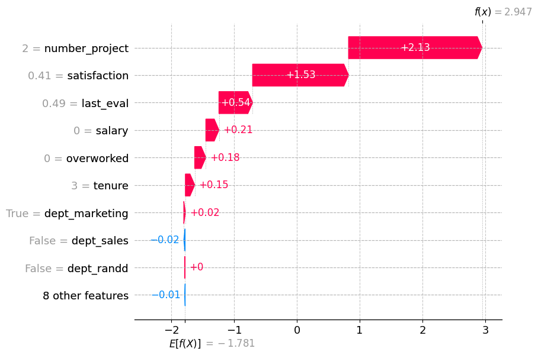

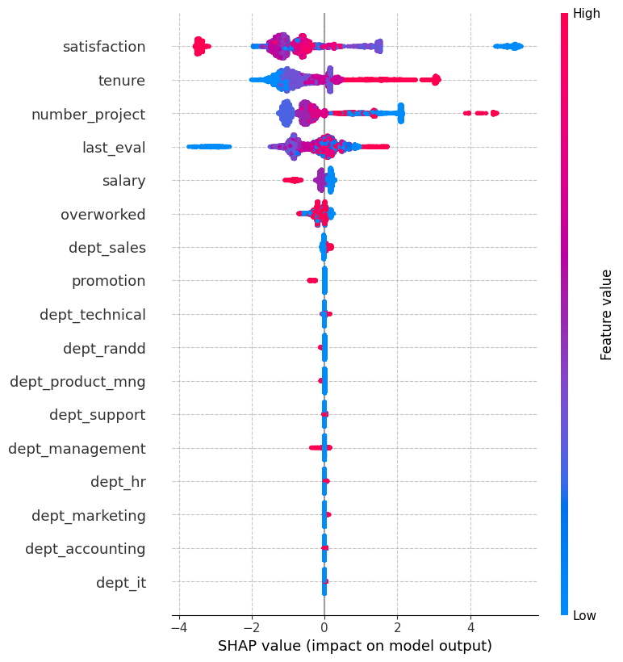

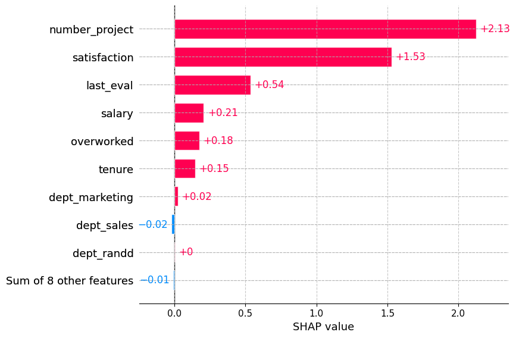

```python
# Make predictions on test data

xg1_best_model = model_xg1.best_estimator_ # Store best model parameters for later testing
y_pred_train = xg1_best_model.predict(X_train)
explainer = shap.TreeExplainer(xg1_best_model)

# Compute the SHAP values for a set of observations
shap_values = explainer(X_train)

plt.grid(True, linestyle='--', alpha=0.7)

# Plot the SHAP values
shap.plots.waterfall(shap_values[0])
plt.grid(True, linestyle='--', alpha=0.7)
shap.summary_plot(shap_values, X_train)
plt.grid(True, linestyle='--', alpha=0.7)
shap.plots.bar(shap_values[0])
```

```
[12:10:53] WARNING: /workspace/src/c_api/c_api.cc:1240: Saving into deprecated binary model format, please consider using `json` or `ubj`. Model format will default to JSON in XGBoost 2.2 if not specified.
```

[figure not shown]

[figure not shown]

```python
explainer = shap.TreeExplainer(xg1_best_model)

# Calculate SHAP values for the test set
shap_values = explainer.shap_values(X_test)

# Plot SHAP summary plot
shap.summary_plot(shap_values, X_test, feature_names=df1.columns)

# Add a title to the plot
plt.title('SHAP Summary Plot')

# Display the plot
plt.show()
```

## Construct Model - XGBoost - `xg2` - No Departments

### Import Data - `xg2` - No Departments

Two datasets for model performance comparison, :

- `salifort_data_FE.csv` is the full data set feature engineered with `salary` encoded to ordinal, `avg_mth_hrs` binary encoded to `overwork` and dept encoded with dummies
- `salifort_data_FE_focus.csv` (THIS DATA) is the same data with the dummy encoded dept fields removed.

`Dept` appears to have low correlation across the dataset and I'm curious how much the models are influenced with low correlation features. It turns out that low correlation features have little impact on model performance. which is no surprise really!

#### Code flags:

**rerun** = flag to identify the first run of the model comparisons and write a NEW Results.csv file. 0 = first run and a new file will be created with headers / 1 = Continuation, Results will be appended to the file.

**dataset** = Text indicating which dataset is being used, added to the model description during csv save to Results.csv

**model_prefix** = text indicating which ML model is being used, added to the model description during csv save to Results.csv

**refit** = fits with this data takes 20-30 mins. 1 = Fit Data and Pickle Save Model 0 = don't refit data, Pickle load model

**fitver** = suffix added to pickle save model file name to help distinguish xg1 - all feature or xg2 and focus features datasets

```python
# Load cleaned dataset into a dataframe
print("Started / Last Run =", dt.now().strftime("%Y-%m-%d %H:%M:%S"),"\n")

# Feature engineering on salary, avg_mnth_hrs, outliers removed, departments removed
df2 = pd.read_csv(load_path + "data_cleaned_NoOl_FE_NoDept.csv", index_col = False)

# Always sort the index
df2.sort_index(axis=1, inplace=True)

# model_prefix : Str prefix for results.csv added to dataset
model_prefix   = 'xg2'

# dataset : Str = dataset save name for results.csv
dataset        = 'NOdept'

# fitver : Str = Suffix for the pickle save filename
fitver         = 'NOdept'

# rerun : int =  Flag to set 1 = append to Results.csv / 0 = Overwrite with new file
rerun          = 1

# refit : int - 1 = Fit Data and Save model / 0 = load model, don't fit data
refit          = 0         # 1 = Fit Data and Save model / 0 = load model, don't fit data

print("df2 - FOCUS FEATURES - Feature engineering on salary, avg_mnth_hrs, dept REMOVED, outliers removed\n")

# Display dataframe columns
print(df2.info())
```

```
Started / Last Run = 2023-12-04 12:10:55

df2 - FOCUS FEATURES - Feature engineering on salary, avg_mnth_hrs, dept REMOVED, outliers removed

<class 'pandas.core.frame.DataFrame'>
RangeIndex: 11167 entries, 0 to 11166
Data columns (total 8 columns):
 #   Column          Non-Null Count  Dtype
---  ------          --------------  -----
 0   last_eval       11167 non-null  float64
 1   left            11167 non-null  float64
 2   number_project  11167 non-null  float64
 3   overworked      11167 non-null  int64
 4   promotion       11167 non-null  float64
 5   salary          11167 non-null  int64
 6   satisfaction    11167 non-null  float64
 7   tenure          11167 non-null  float64
dtypes: float64(6), int64(2)
memory usage: 698.1 KB
None
```

### Prepare data for modelling - `xg2`

```python
model_data2 = df2.copy()
```

### Isolate the outcome and feature variables - `xg2`

```python
# Isolate the outcome variable
Y2 = model_data2['left']

# Select & Isolate the feature variables and drop the outcome variable
X2 = model_data2.copy()
X2 = X2.drop('left', axis = 1)

#X = sm.add_constant(X)

X2.columns
```

```
Index(['last_eval', 'number_project', 'overworked', 'promotion', 'salary', 'satisfaction', 'tenure'], dtype='object')
```

### Train Test split data - `model_xg2`

```python
# Prepare training and test data
X_train2, X_test2, y_train2, y_test2 = train_test_split(X2,Y2, test_size=0.25, stratify=Y, random_state=0)
```

### Instantiate model - XGBoost - GridSearch - `model_xg2` - Train data

```python
# Instantiate model

# xgb.XGBRegressor() for regression problems, xgb.XGBClassifier() for classification problems
xgc = XGBClassifier(random_state=0)


# Assign a dictionary of hyperparameters to search over
cv_params = {'learning_rate': [0.05, 0.1, 0.15],
             'max_depth': [3, 4, 5, 6, 8],
             'min_child_weight': [1, 3, 5, 7],
             'gamma': [0.0, 0.1, 0.2],
             'colsample_bytree': [0.3, 0.4]

             }


# Assign a dictionary of scoring metrics to capture
scoring = ('accuracy', 'precision', 'recall', 'f1', 'roc_auc')

# Instantiate GridSearch
model_xg2 = GridSearchCV(xgc, cv_params, scoring=scoring, cv=4, refit='roc_auc')
```

### Fit Data - XGBoost - Grid Search - `model_xg2` - Train data

```python
%%time
print("Started / Last Run =", dt.now().strftime("%Y-%m-%d %H:%M:%S"))
# Fit data
if refit == 1:
    model_xg2.fit(X_train2, y_train2) # --> Wall time:  18-21 mins
    beepr()

print("Finish Time =", dt.now().strftime("%H:%M:%S"))
```

```
Started / Last Run = 2023-12-04 12:10:56
Finish Time = 12:10:56
CPU times: user 593 µs, sys: 133 µs, total: 726 µs
Wall time: 851 µs
```

### Read / Write Pickle

```python
## Write pickle

if refit == 1: # refit = 1 run the fit and save the model
    write_pickle(model_path, model_xg2, 'hr_xg2-'+fitver)

# Read in pickle
if refit == 0: # refit = 0 load model, don't  fit the data
    model_xg2 = read_pickle(model_path, 'hr_xg2-'+fitver)
```

### Get GridSearch best results - XGBoost - `model_xg2` - Train data

```python
# Get the parameters of the best-performing model
print("Best Parameters : ", model_xg2.best_params_)

# Get the average f1 score of the best-performing model
print("Best Score      : ", model_xg2.best_score_)

# Get the best estimators of the parameters
print("Best Estimator  : ", model_xg2.best_estimator_)
```

```
Best Parameters :  {'colsample_bytree': 0.3, 'gamma': 0.2, 'learning_rate': 0.15, 'max_depth': 4, 'min_child_weight': 1}
Best Score      :  0.9806005736725114
Best Estimator  :  XGBClassifier(base_score=None, booster=None, callbacks=None,
              colsample_bylevel=None, colsample_bynode=None,
              colsample_bytree=0.3, device=None, early_stopping_rounds=None,
              enable_categorical=False, eval_metric=None, feature_types=None,
              gamma=0.2, grow_policy=None, importance_type=None,
              interaction_constraints=None, learning_rate=0.15, max_bin=None,
              max_cat_threshold=None, max_cat_to_onehot=None,
              max_delta_step=None, max_depth=4, max_leaves=None,
              min_child_weight=1, missing=nan, monotone_constraints=None,
              multi_strategy=None, n_estimators=None, n_jobs=None,
              num_parallel_tree=None, random_state=0, ...)
```

### Prepare and Save Results - XGBoost - GridSearch - `model_xg2` - Train data

```python
pd.options.display.float_format = '{:.3f}'.format
model_xg2_results = format_GS_results(model_prefix+' - '+dataset+' - '+'GS train', model_xg2, 'auc')
model_xg2_results.to_csv("./Results.csv", mode='a', index=True, header=False)
```

## Performance Results & Comparisons - GridSearch - `model_xg2` - Train data

### Display Results

```python
pd.options.display.float_format = '{:.3f}'.format
print(model_xg2_results)
display_results()
```

```
                     Model  Precision  Recall    F1  Accuracy   AUC
0  xg2 - NOdept - GS train      0.960   0.913 0.936     0.979 0.981
```

|  | Model | Precision | Recall | F1 | Accuracy | AUC | Predict Leave | Predict Stay |
| --- | --- | --- | --- | --- | --- | --- | --- | --- |
| 12 | xg1 - ALLFeat - train | 0.980 | 0.980 | 0.980 | 0.980 | 0.987 | 0.939 | 0.988 |
| 11 | xg1 - ALLFeat - test | 0.979 | 0.979 | 0.979 | 0.979 | 0.986 | 0.938 | 0.988 |
| 10 | xg1 - ALLFeat - GS train | 0.957 | 0.910 | 0.933 | 0.978 | 0.982 | NaN | NaN |
| 13 | xg2 - NOdept - GS train | 0.960 | 0.913 | 0.936 | 0.979 | 0.981 | NaN | NaN |
| 5 | dt1 - ALLFeat - test | 0.978 | 0.979 | 0.978 | 0.979 | 0.979 | 0.936 | 0.987 |
| 8 | dt2 - NOdept - test | 0.978 | 0.979 | 0.978 | 0.979 | 0.979 | 0.936 | 0.987 |
| 6 | dt1 - ALLFeat - train | 0.978 | 0.979 | 0.978 | 0.979 | 0.979 | 0.935 | 0.987 |
| 9 | dt2 - NOdept - train | 0.978 | 0.979 | 0.978 | 0.979 | 0.979 | 0.935 | 0.987 |
| 7 | dt2 - NOdept - GS train | 0.951 | 0.914 | 0.932 | 0.977 | 0.974 | NaN | NaN |
| 4 | dt1 - ALLFeat - GS train | 0.951 | 0.914 | 0.932 | 0.977 | 0.974 | NaN | NaN |
| 1 | lr1 - ALLFeat - train | 0.796 | 0.827 | 0.804 | 0.827 | 0.892 | 0.328 | 0.900 |
| 3 | lr2 - NOdept - train | 0.793 | 0.825 | 0.802 | 0.825 | 0.892 | 0.318 | 0.900 |
| 0 | lr1 - ALLFeat - test | 0.794 | 0.822 | 0.803 | 0.822 | 0.882 | 0.341 | 0.897 |
| 2 | lr2 - NOdept - test | 0.795 | 0.823 | 0.804 | 0.823 | 0.882 | 0.343 | 0.898 |

### Feature Importance - GridSearch - `model_xg2` - Train data

```
[12:10:56] WARNING: /workspace/src/c_api/c_api.cc:1240: Saving into deprecated binary model format, please consider using `json` or `ubj`. Model format will default to JSON in XGBoost 2.2 if not specified.
```

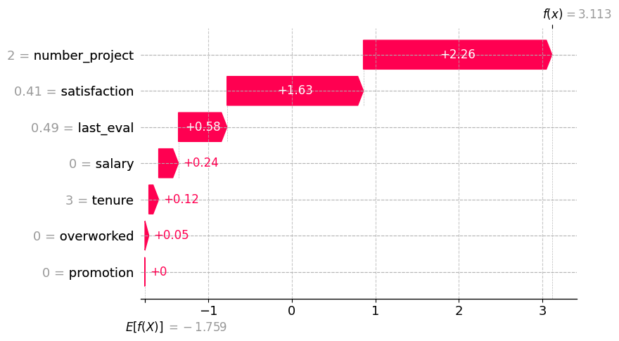

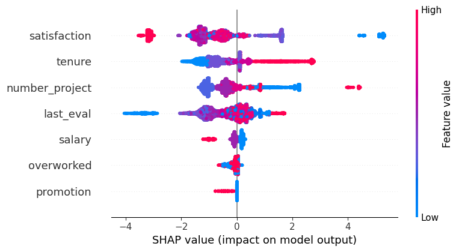

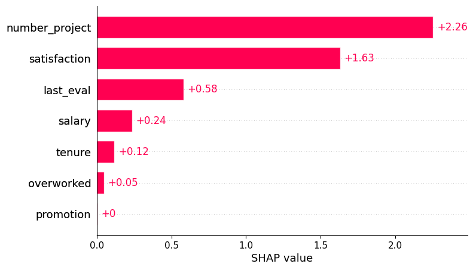

```python
# Make predictions on test data

xg2_best_model = model_xg2.best_estimator_ # Store best model parameters for later testing
y_pred_train2 = xg2_best_model.predict(X_train2)
explainer = shap.TreeExplainer(xg2_best_model)

# Compute the SHAP values for a set of observations
shap_values = explainer(X_train2)

plt.grid(True, linestyle='--', alpha=0.7)

# Plot the SHAP values
shap.plots.waterfall(shap_values[0])
shap.summary_plot(shap_values, X_train2)
shap.plots.bar(shap_values[0])
```

### Make Predictions - XGBoost - best_model - `model_xg2` - Test data

```python
# Make predictions on test data

# Store best model parameters for later testing
xg2_best_model = model_xg2.best_estimator_
y_pred_test2 = xg2_best_model.predict(X_test2)
y_pred_train2 = xg2_best_model.predict(X_train2)
```

### Classification Report

```python
classification_report_summary(model_prefix+' - '+dataset+' - '+'test', y_test2, y_pred_test2)
```

```
Classification Report :  xg2 - NOdept - test
───────────────────────────────────
                           precision    recall  f1-score   support

Predicted would not leave       0.99      0.99      0.99      2321
    Predicted would leave       0.96      0.93      0.94       471

                 accuracy                           0.98      2792
                macro avg       0.97      0.96      0.97      2792
             weighted avg       0.98      0.98      0.98      2792

Recall        : 92.7813%
f1_score      : 94.1810%
Precision     : 95.6236%
Accuracy      : 98.0659%

───────────────────────────────────
Weighted Average
───────────────────────────────────
Recall        : 98.0659%
f1 Score      : 98.0542%
Precision     : 98.0513%
Support       : 279200.0000%

───────────────────────────────────
Prediction F1 score
───────────────────────────────────
Predict Leave : 94.1810%
Support Stay  : 98.8402%
```

### Prepare and Save Results - `model_xg2` - Test data

```python
model_xg2_results = make_results(model_prefix+' - '+dataset+' - '+'train', xg2_best_model, X_train2, y_train2, y_pred_train2)
model_xg2_results.to_csv("./Results.csv", mode='a', index=True, header=False)


model_xg2_results = make_results(model_prefix+' - '+dataset+' - '+'test', xg2_best_model, X_test2, y_test2, y_pred_test2)
model_xg2_results.to_csv("./Results.csv", mode='a', index=True, header=False)
```

## Performance Results & Comparisons - `model_xg2` - Test data

### Display Results

```python
print(model_xg2_results)
print()
display_results()
```

```
                 Model  Precision  Recall    F1  Accuracy   AUC  Predict Leave  Predict Stay
0  xg2 - NOdept - test      0.981   0.981 0.981     0.981 0.983          0.942         0.988
```

|  | Model | Precision | Recall | F1 | Accuracy | AUC | Predict Leave | Predict Stay |
| --- | --- | --- | --- | --- | --- | --- | --- | --- |
| 12 | xg1 - ALLFeat - train | 0.980 | 0.980 | 0.980 | 0.980 | 0.987 | 0.939 | 0.988 |
| 11 | xg1 - ALLFeat - test | 0.979 | 0.979 | 0.979 | 0.979 | 0.986 | 0.938 | 0.988 |
| 14 | xg2 - NOdept - train | 0.980 | 0.980 | 0.980 | 0.980 | 0.985 | 0.940 | 0.988 |
| 15 | xg2 - NOdept - test | 0.981 | 0.981 | 0.981 | 0.981 | 0.983 | 0.942 | 0.988 |
| 10 | xg1 - ALLFeat - GS train | 0.957 | 0.910 | 0.933 | 0.978 | 0.982 | NaN | NaN |
| 13 | xg2 - NOdept - GS train | 0.960 | 0.913 | 0.936 | 0.979 | 0.981 | NaN | NaN |
| 5 | dt1 - ALLFeat - test | 0.978 | 0.979 | 0.978 | 0.979 | 0.979 | 0.936 | 0.987 |
| 8 | dt2 - NOdept - test | 0.978 | 0.979 | 0.978 | 0.979 | 0.979 | 0.936 | 0.987 |
| 6 | dt1 - ALLFeat - train | 0.978 | 0.979 | 0.978 | 0.979 | 0.979 | 0.935 | 0.987 |
| 9 | dt2 - NOdept - train | 0.978 | 0.979 | 0.978 | 0.979 | 0.979 | 0.935 | 0.987 |
| 7 | dt2 - NOdept - GS train | 0.951 | 0.914 | 0.932 | 0.977 | 0.974 | NaN | NaN |
| 4 | dt1 - ALLFeat - GS train | 0.951 | 0.914 | 0.932 | 0.977 | 0.974 | NaN | NaN |
| 1 | lr1 - ALLFeat - train | 0.796 | 0.827 | 0.804 | 0.827 | 0.892 | 0.328 | 0.900 |
| 3 | lr2 - NOdept - train | 0.793 | 0.825 | 0.802 | 0.825 | 0.892 | 0.318 | 0.900 |
| 0 | lr1 - ALLFeat - test | 0.794 | 0.822 | 0.803 | 0.822 | 0.882 | 0.341 | 0.897 |
| 2 | lr2 - NOdept - test | 0.795 | 0.823 | 0.804 | 0.823 | 0.882 | 0.343 | 0.898 |

### Feature Importance - XGBoost - `model_xg2` - Test Data

```
[12:10:59] WARNING: /workspace/src/c_api/c_api.cc:1240: Saving into deprecated binary model format, please consider using `json` or `ubj`. Model format will default to JSON in XGBoost 2.2 if not specified.
```

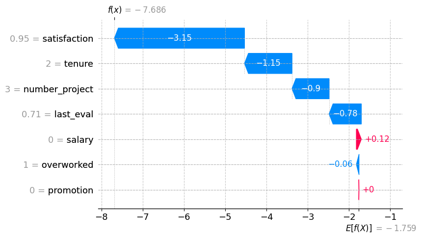

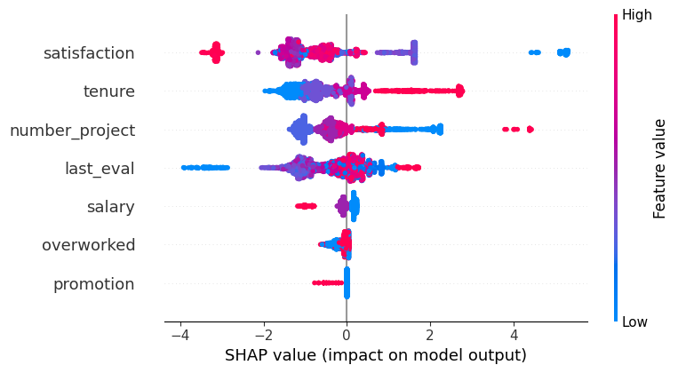

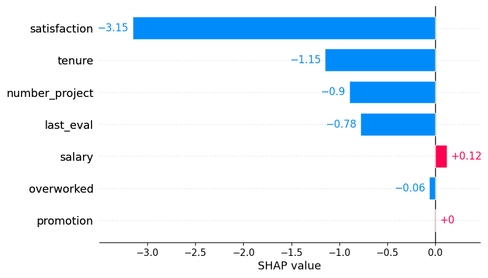

```python
# Make predictions on test data

xg2_best_model = model_xg2.best_estimator_ # Store best model parameters for later testing
y_pred_test2 = xg2_best_model.predict(X_test2)
explainer = shap.TreeExplainer(xg2_best_model)

# Compute the SHAP values for a set of observations
shap_values = explainer(X_test2)

plt.grid(True, linestyle='--', alpha=0.7)

# Plot the SHAP values
shap.plots.waterfall(shap_values[0])
shap.summary_plot(shap_values, X_test2)
shap.plots.bar(shap_values[0])
```